# Why Statistics?

STA9661

## Types of data analysis

- Quantitative Methods
  - Testing theories using numbers
- Qualitative Methods
  - Testing theories using language
  - Magazine articles/Interviews
  - Conversations
  - Newspapers
  - Media broadcasts

## The research process

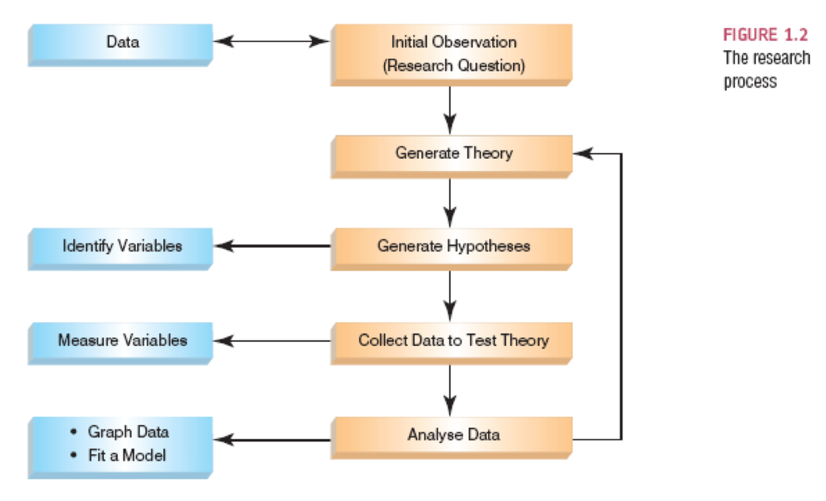

## Initial observation

- Find something that needs explaining
  - Observe the real world
  - Read other research
- Test the concept: collect data
  - Collect data to see whether your hunch is correct
  - To do this you need to define variables
    - Anything that can be measured and can differ across entities or time

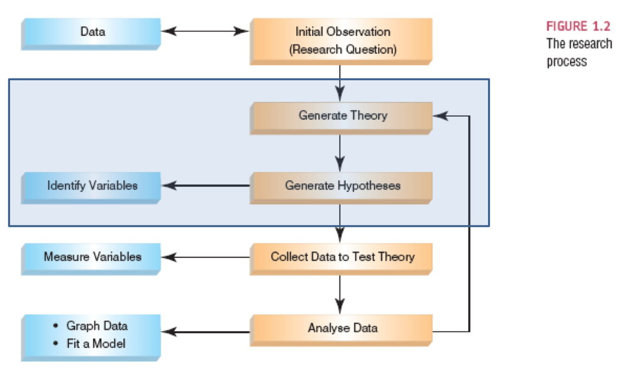

## Generating and testing theories

- Theory
  - A hypothesized general principle or set of principles that explains known findings about a topic and from which new hypotheses can be generated.
- Hypothesis
  - A supposition from a theory.
  - e.g. the number of people turning up for a Big Brother audition that have narcissistic personality disorder is higher than the general level (1%) in the population.
- Falsification
  - The act of disproving a theory or hypothesis.

A table of the number of people at the *Big Brother* audition split by whether they had narcissistic personality disorder and whether they were selected as contestants by the producers

|  | No Disorder | Disorder | Total |
| --- | --- | --- | --- |
| Selected | 3 | 9 | 12 |
| Rejected | 6805 | 845 | 7650 |
| Total | 6808 | 854 | 7662 |

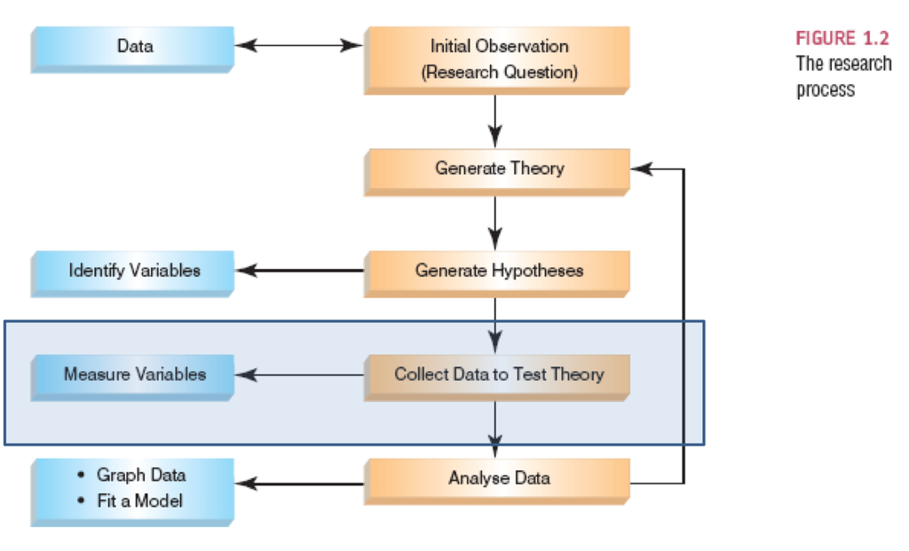

## Data collection 1: what to measure

- Hypothesis:
  - Coca-Cola kills sperm.
- Independent Variable
  - The proposed cause
  - A predictor variable
  - A manipulated variable (in experiments)
  - Coca-Cola in the hypothesis above
- Dependent Variable
  - The proposed effect
  - An outcome variable
  - Measured not manipulated (in experiments)
  - Sperm in the hypothesis above

## Levels of measurement

- Categorical (entities are divided into distinct categories):
  - Binary variable: There are only two categories
    - e.g. dead or alive.
  - Nominal variable: There are more than two categories
    - e.g. whether someone is an omnivore, vegetarian, vegan, or fruitarian.
  - Ordinal variable: The same as a nominal variable but the categories have a logical order
    - e.g. whether people got a fail, a pass, a merit or a distinction in their exam.
- Continuous (entities get a distinct score):
  - Interval variable: Equal intervals on the variable represent equal differences in the property being measured
    - e.g. the difference between 6 and 8 is equivalent to the difference between 13 and 15.
  - Ratio variable: The same as an interval variable, but the ratios of scores on the scale must also make sense
    - e.g. a score of 16 on an anxiety scale means that the person is, in reality, twice as anxious as someone scoring 8.

## Measurement error

- Measurement error
  - The discrepancy between the actual value we’re trying to measure, and the number we use to represent that value.
- Example:
  - You (in reality) weigh 180 lb.
  - You stand on your bathroom scales and they say 185 lb.
  - The measurement error is 5 lb.

## Validity and reliability

- Validity: Is the instrument measuring what it claims to measure?
- Reliability
  - The ability of the measure to produce the same results under the same conditions
  - Test–Retest Reliability: The ability of a measure to produce consistent results when the same entities are tested at two different points in time.

## Data collection 2: how to measure

- Correlational research:
  - Observing what naturally goes on in the world without directly interfering with it.
- Cross-sectional research:
  - This term implies that data come from people at different age points, with different people representing each age point.
- Experimental research:
  - One or more variable is systematically manipulated to see their effect (alone or in combination) on an outcome variable.
  - Statements can be made about causality.

## Methods of data collection

- Between-group/between-subject/independent
  - Different entities in experimental conditions
- Repeated-measures (within-subject)
  - The same entities take part in all experimental conditions.
  - Economical
  - Practice effects
  - Fatigue

## Types of variation

- Systematic Variation
  - Differences in performance created by a specific experimental manipulation.
- Unsystematic Variation
  - Differences in performance created by unknown factors.
    - Age, gender, IQ, time of day, measurement error, etc.
- Randomization
  - Minimizes unsystematic variation.

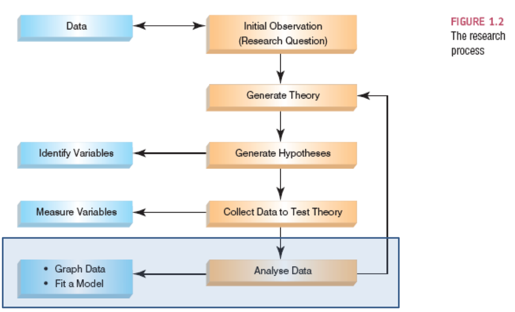

## Analyzing data: histogram

- Frequency distributions (aka Histograms)
  - A graph plotting values of observations on the horizontal axis, with a bar showing how many times each value occurred in the data set.
- The ‘Normal’ Distribution
  - Bell-shaped
  - Symmetrical around the centre

## Normal distribution

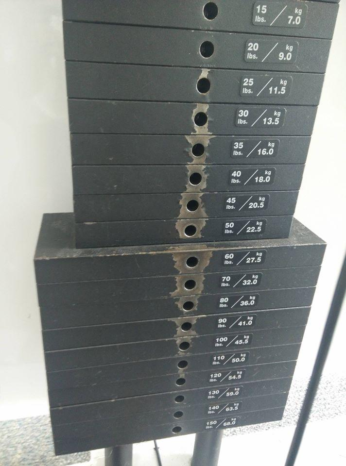

## Normal distribution

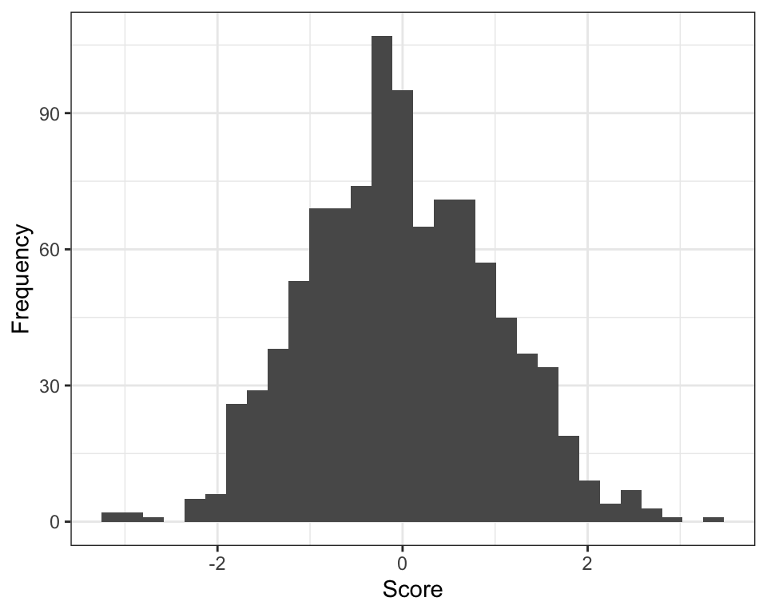

## Properties of frequency distributions

- Skewness
  - The symmetry of the distribution.
  - Positive skew (scores bunched at low values with the tail pointing to high values).
  - Negative skew (scores bunched at high values with the tail pointing to low values).

## A positively skewed distribution

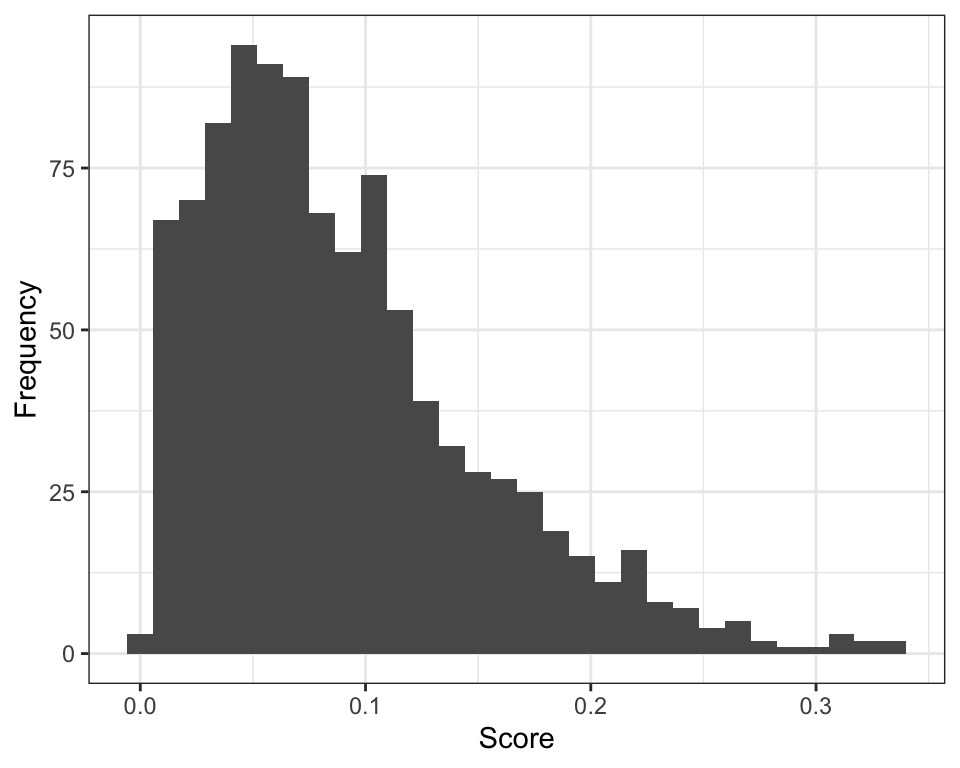

## A negatively skewed distribution

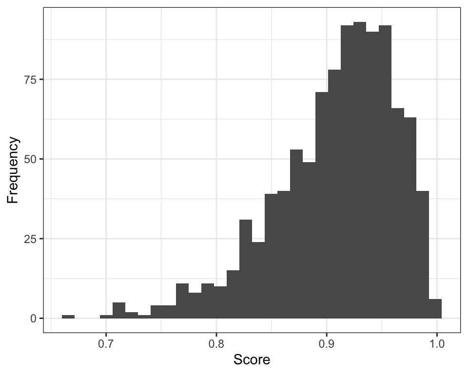

## Kurtosis

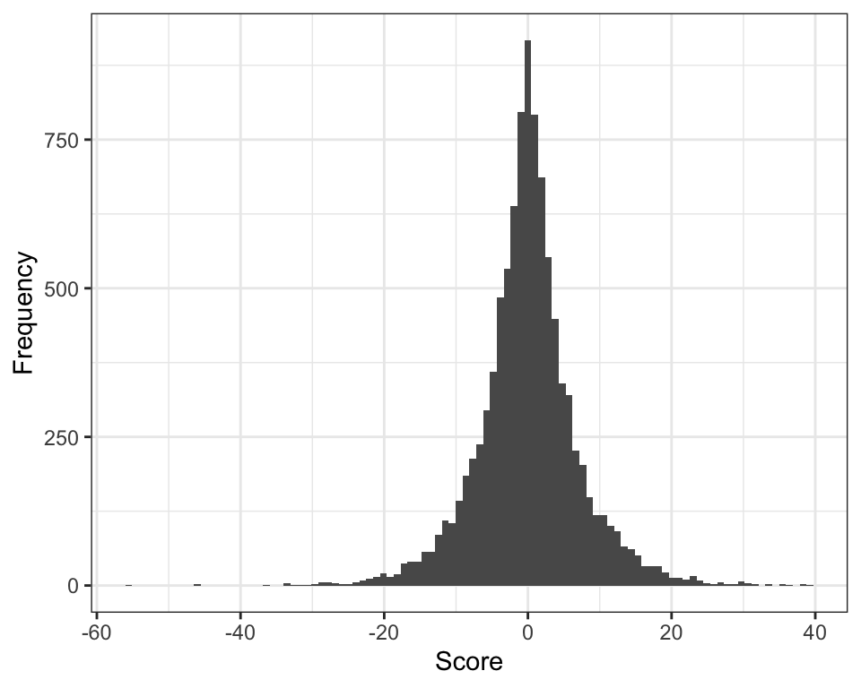

## Central tendency: The Mode

- Mode
  - The most frequent score
- Unimodal, Bimodal, multimodal

## A bimodal distribution

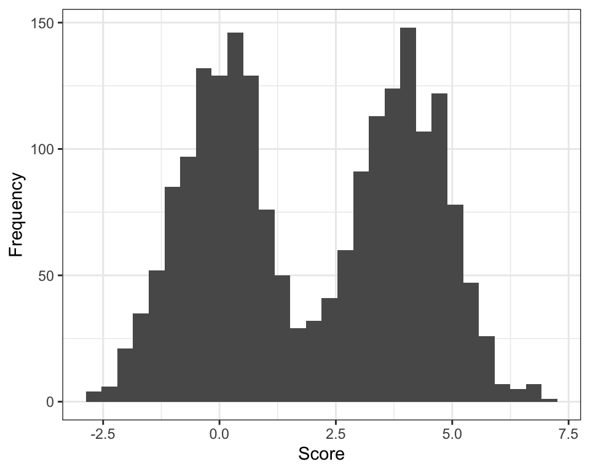

## Central tendency: the median

- Median
  - The middle score when scores are ordered.
- Example
  - Number of friends of 11 Facebook users.

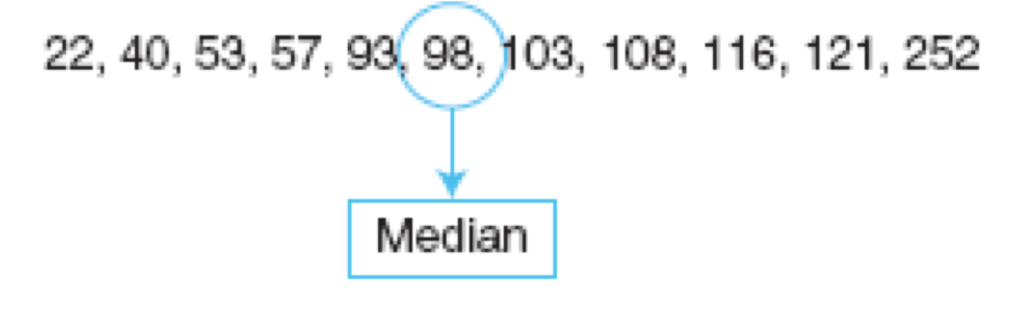

## Central tendency: the mean

- Mean
  - The sum of scores divided by the number of scores.
  - Number of friends of 11 Facebook users.
    $$\bar{x} = \frac{\sum_{i=1}^{n} x_i}{n}$$

$$\sum_{i=1}^{n} x_i = 22 + 40 + 53 + \cdots + 121 + 252 = 1063$$

$$\bar{x} = \frac{\sum_{i=1}^{n} x_i}{n} = 1063/11 = 96.64$$

## The dispersion: range

- The Range: the smallest score subtracted from the largest
- Example
  - Number of friends of 11 Facebook users.
  - 22, 40, 53, 57, 93, 98, 103, 108, 116, 121, 252
  - Range = 252 – 22 = 230
  - Very easily affected by outliers

## The dispersion: the interquartile range (IQR)

- Quartiles : the three values that split the sorted data into four equal parts.
  - Second quartile = median.
  - Lower quartile = median of lower half of the data.
  - Upper quartile = median of upper half of the data.
- IQR: range of the middle 50%.

## Going beyond the data: z-scores

- z-scores
  - Standardizing a score with respect to the other scores in the group.
  - Expresses a score in terms of how many standard deviations it is away from the mean.
  - The distribution of z-scores has a mean of 0 and SD = 1.
  - The z-score of $i$th score $x_i$ is calculated by
    $$z_i = \frac{x_i - \bar{x}}{s}$$

## Properties of z-scores

(assuming the original distribution is approximately normal)

- 1.96 cuts off the top 2.5% of the distribution.
- -1.96 cuts off the bottom 2.5% of the distribution.
- As such, 95% of z-scores lie between -1.96 and 1.96.
- 99% of z-scores lie between -2.58 and 2.58.
- 99.9% of them lie between -3.29 and 3.29.

## Types of Hypotheses

- Null hypothesis, $H_0$
  - There is no effect.
  - e.g. Big Brother contestants and members of the public are not different in their scores on personality disorder questionnaires
- The alternative hypothesis, $H_1$
  - e.g. Big Brother contestants score higher on personality disorder questionnaires than members of the public